# Ejercicio extendido - ACP incluyendo los metadatos de precisión

## 2.2 El nulo del error NO es aleatorio (nulo estructural)

**Si no se midió la variable, tampoco existe su error.** El nulo del error depende del nulo del valor, por lo que no es MCAR (Missing Completely At Random).

```r
nulo_estructural(mat71, c("pl_rade", "pl_orbper", "st_teff", "sy_dist", "pl_eqt")) %>%
  kable(caption = "¿Coincide el nulo del error con el nulo de su variable base?") %>%
  kable_styling(bootstrap_options = c("striped", "hover"))
```

¿Coincide el nulo del error con el nulo de su variable base?

| variable | error | n_nulo_valor | n_nulo_error | pct_coincide | interpretacion |
| --- | --- | --- | --- | --- | --- |
| pl_rade | pl_radeerr1 | 3325 | 3387 | 99.0 | nulo ESTRUCTURAL (no MCAR) |
| pl_orbper | pl_orbpererr1 | 848 | 1390 | 91.3 | nulo ESTRUCTURAL (no MCAR) |
| st_teff | st_tefferr1 | 1781 | 2150 | 94.1 | nulo ESTRUCTURAL (no MCAR) |
| sy_dist | sy_disterr1 | 83 | 128 | 99.3 | nulo ESTRUCTURAL (no MCAR) |
| pl_eqt | pl_eqterr1 | 4478 | 4576 | 98.4 | nulo ESTRUCTURAL (no MCAR) |

**Por qué importa:** imputar `pl_radeerr1` donde no existe `pl_rade` significaría fabricar una incertidumbre para una medida que nunca se hizo. No solo es estadísticamente dudoso, es **conceptualmente incorrecto**: se le estaría atribuyendo precisión a un dato inexistente.

## 2.3 Heterocedasticidad: el error crece con la magnitud

```r
het <- heterocedasticidad(raw_data, c("sy_dist", "pl_orbper", "pl_rade",
                                      "st_rad", "st_mass", "st_teff"))
het %>%
  kable(caption = "Correlación log10(valor) vs log10(error superior). r alta = el error escala con la magnitud",
        digits = 3) %>%
  kable_styling(bootstrap_options = c("striped", "hover"))
```

Correlación log10(valor) vs log10(error superior). r alta = el error escala con la magnitud

| variable | error | n | r_log | lectura |
| --- | --- | --- | --- | --- |
| sy_dist | sy_disterr1 | 34751 | 0.979 | MUY fuerte: el error escala con la magnitud |
| pl_orbper | pl_orbpererr1 | 31700 | 0.826 | MUY fuerte: el error escala con la magnitud |
| pl_rade | pl_radeerr1 | 24094 | 0.502 | fuerte |
| st_rad | st_raderr1 | 27869 | 0.409 | fuerte |
| st_mass | st_masserr1 | 25246 | 0.359 | débil |
| st_teff | st_tefferr1 | 32686 | 0.171 | débil |

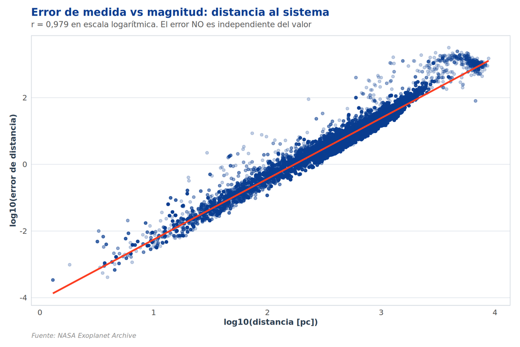

Heterocedasticidad: a mayor distancia, mayor error de medida (r = 0,979)

```r
tibble(
  dist = suppressWarnings(as.numeric(raw_data$sy_dist)),
  err  = suppressWarnings(as.numeric(raw_data$sy_disterr1))
) %>%
  filter(!is.na(dist), !is.na(err), dist > 0, err > 0) %>%
  ggplot(aes(x = log10(dist), y = log10(err))) +
  geom_point(alpha = 0.25, color = nasa_col("primary"), size = 1.4) +
  geom_smooth(method = "lm", color = nasa_col("secondary"), linewidth = 1,
              se = FALSE) +
  labs(title = "Error de medida vs magnitud: distancia al sistema",
       subtitle = "r = 0,979 en escala logarítmica. El error NO es independiente del valor",
       x = "log10(distancia [pc])", y = "log10(error de distancia)",
       caption = "Fuente: NASA Exoplanet Archive") +
  theme_nasa()
```

**Consecuencia:** el error de `sy_dist` está correlacionado con `sy_dist` en **r = 0,979**. Al meter ambas columnas en el ACP, la primera componente captará una dimensión de *“magnitud de la medida”* en vez de una dimensión astrofísica. Es un artefacto del instrumento, no de los exoplanetas.